# 통계 방법론1 중간대체

응용통계학과 이준혁

2023-10-28(토)

# 목차

## 귀납적 추론은 새로운 지식이 세상에 들어오는 유일한 과정이다.($\epsilon$이 unknown일 때)

- 생각하기
- Part2 Statistical Method - 요약, 비교, 관계
  - 통계적 의사 결정 Statistical Decision Making
  - 확률 분포와 그 응용
  - 확증적 비교 방법 Confirmatory Comparisons
  - 단순 회귀 분석 Simple Regression Analysis
  - 다중 회귀 분석 Multiple Linear Regression
- 중요한 기본 R함수 정리

# 생각하기

- 자유도
- 통계적 의사 결정
  - 모든 관심 특성은 **변수**이다.
  - 모든 통계량은 고유의 **표본 분포(sampling distribution)**를 갖는다.
    - 이는 표본 추출에 의하여 발생하는 **표본 오차(sampling error)**를 수량화한다.
  - 표본 오차(sampling error)가 존재한다면, 이를 **의사결정에 반영**할 수 있어야 한다.
- 연속형일 때는 측정 단위가 매우 중요하다 -> 표준화 적용
- 다변량에서 차원 축소를 진행할 때 y값을 다 표준화하는 게 추세이다.
- 쌍체 검정은 쌍별 차이를 고려하기 때문에 개체 내의 변동성은 제거하고 측정값 간의 차이에만 집중을 할 수 있다.
  - 동일한 주체로부터 두 번의 측정을 받기 때문에, 주체의 개별적인 차이나 특성에 의한 영향을 제거할 수 있다.
- 개선 활동의 검증에는 일반적으로 **방향성 가설**이 적절하다.
- 설명 변수들간 선형 종속 관계일 때 다중 공선성이 존재한다.
  - 왜 문제인가?
    - $(X'X)^-1$이 불안정해지고, $var(\hat\beta)$도 불안해지고, $\hat y$도 불안정해진다.
  - 파생변수를 생성한뒤에는 활용한 기존 변수는 제거를 해야하는가?
- ML 적용
  - heuristics에 의해서 $\alpha=0.05$로 설정하는 것처럼 머신러닝에서는 heuristics에 의해 선택되는 것이 많이 있다.
  - A/B test 방법 중에 하나가 T-test로 봐도 되는 것인가?
  - Base인 A모델과 B모델을 비교하고자한다.
  - 모델 선택도 heuristics에 의해서 좋은 모델을 선택한다.
    - $H_0 : \mu_B \leq \mu_A$: B모델의 성능은 A모델의 성능보다 나쁘거나 같다.
    - $H_1 : \mu_B > \mu_A$: B모델의 성능은 A모델의 성능보다 좋다.
    - 같은 샘플을 가지고 ML모델을 적용해서 T-test를 통해서 모델을 비교한다.(대응 T-test)
  - Multiple Comparison: 단순 2모델 비교가 아닐 때는 Multiple Comparison
    - 본페로니 보정을 통해서 더 엄격한 $\alpha$값을 설정
      $$\frac{\alpha}{모델 개수}$$

# 1. 통계적 의사 결정

Statistical Decision Making

## 1.1. 모수와 통계량

- **모수:** 모집단의 특징으로 **상수(constant)**
- **통계량:** 표본에서의 결과이며 **변수(variable)**

```r
unit1 = c(10, 10, 10, 50, 30, 40, 50, 40, 30 ,50)
unit2 = c(20, 30, 40, 10, 20, 20, 20, 30, 50, 40)

results <- ((unit1 + unit2) / 2) %>% print()
```

```
##  [1] 15 20 25 30 25 30 35 35 40 45
```

```r
# 결과를 데이터 프레임으로 변환
df <- data.frame(Sample.Mean = results)
df
```

```
##    Sample.Mean
## 1           15
## 2           20
## 3           25
## 4           30
## 5           25
## 6           30
## 7           35
## 8           35
## 9           40
## 10          45
```

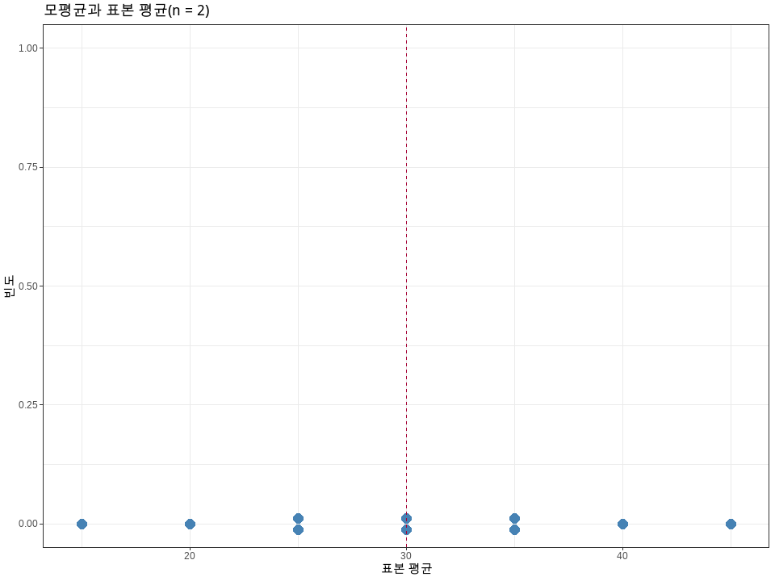

```r
# 도트 플롯으로 시각화하기
ggplot(df, aes(x = Sample.Mean)) +
  geom_dotplot(binwidth = 0.5, stackdir = "center", color=sbl, fill= sbl) +
  labs(title="모평균과 표본 평균(n = 2)", x="표본 평균", y="빈도") +
  ylim(0, 1) +
  theme_bw() +
  geom_vline(xintercept=30, linetype="dashed", color = lre)
```

- 모든 통계량은 고유의 분포를 갖는다. 이를 **표본 분포(sampling distribution)**라고 한다.
- 모든 모집단의 평균이 의미가 있는가?
  - 평균만으로는 분포의 형태, 이상치의 영향, 데이터가 가지는 의미를 파악하기에는 어려움이 있어 보인다.

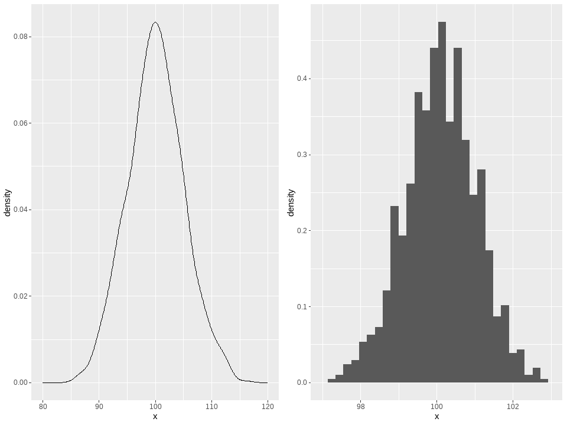

```r
# 1. Normal Population Distribution
set.seed(123)
population1 <- rnorm(1000, mean=100, sd=5)
sample_means1 <- replicate(1000, mean(sample(population1, size=30)))

p1 <- ggplot(data.frame(x=population1), aes(x)) + geom_density() + xlim(80, 120)
p2 <- ggplot(data.frame(x=sample_means1), aes(x)) + geom_histogram(aes(y=..density..), bins=30) + xlim(97, 103)
gridExtra::grid.arrange(p1, p2, ncol = 2)
```

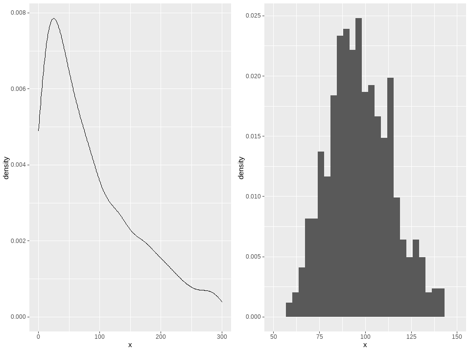

```r
# 2. Gamma Distribution
population2 <- rgamma(1000, shape=1, scale=100)
sample_means2 <- replicate(1000, mean(sample(population2, size=30)))

p3 <- ggplot(data.frame(x=population2), aes(x)) + geom_density() + xlim(0, 300)
p4 <- ggplot(data.frame(x=sample_means2), aes(x)) + geom_histogram(aes(y=..density..), bins=30) + xlim(50, 150)
gridExtra::grid.arrange(p3, p4, ncol = 2)
```

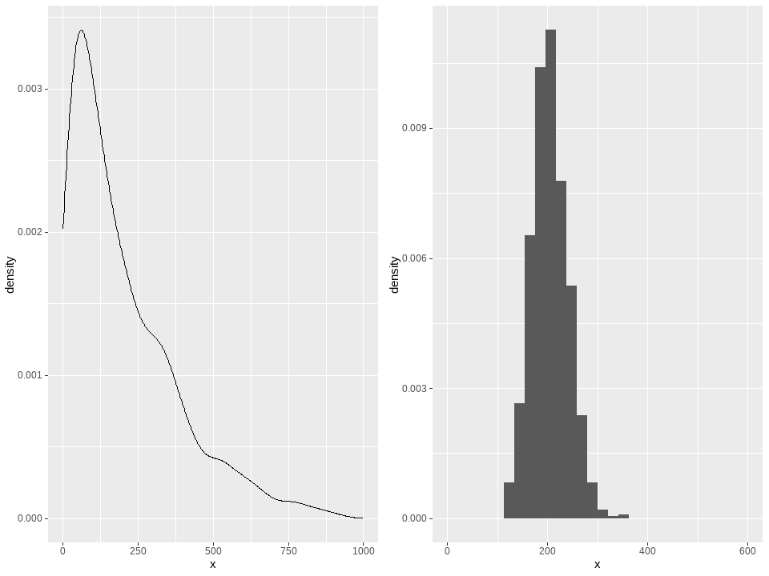

```r
# 3. Exponential Distribution
population3 <- rexp(1000, rate=0.005)
sample_means3 <- replicate(1000, mean(sample(population3, size=30)))

p5 <- ggplot(data.frame(x=population3), aes(x)) + geom_density() + xlim(0, 1000)
p6 <- ggplot(data.frame(x=sample_means3), aes(x)) + geom_histogram(aes(y=..density..), bins=30) + xlim(0, 600)
gridExtra::grid.arrange(p5, p6, ncol = 2)
```

### 대수의 법칙

Law of Large Numbers

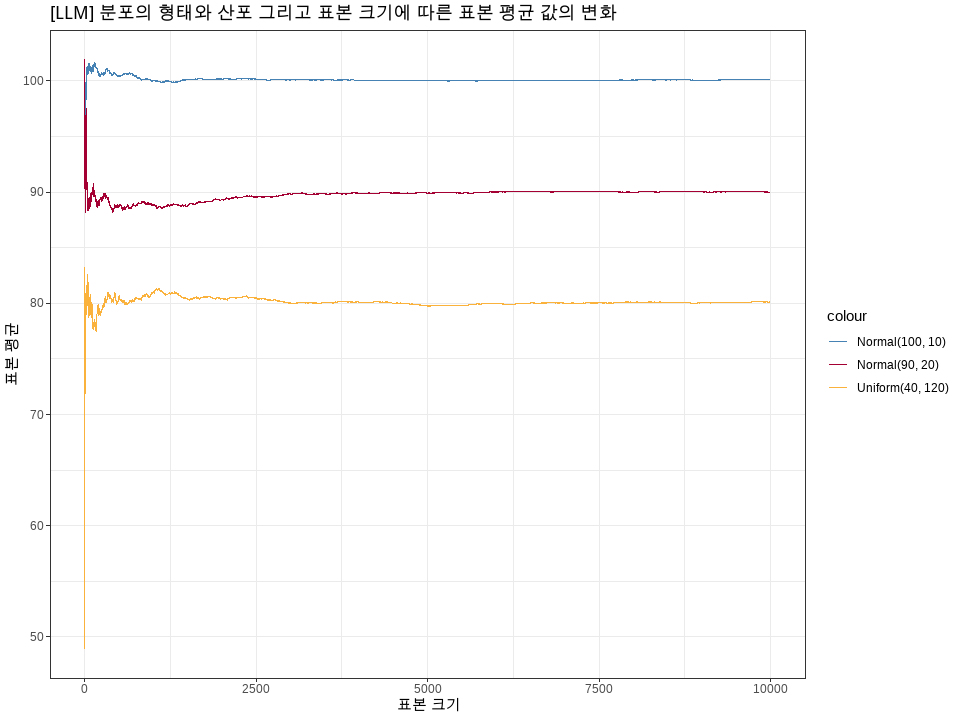

```r
# 데이터 생성
n <- 10000

# Normal(100, 10)
normal_1 <- rnorm(n, mean=100, sd=10)
cum_normal_1 <- cumsum(normal_1) / (1:n)

# Normal(90, 20)
normal_2 <- rnorm(n, mean=90, sd=20)
cum_normal_2 <- cumsum(normal_2) / (1:n)

# Uniform(40, 120)
uniform_data <- runif(n, min=40, max=120)
cum_uniform <- cumsum(uniform_data) / (1:n)

# 그래프 그리기
plot_df <- data.frame(
  Iteration = 1:n,
  Normal_100_10 = cum_normal_1,
  Normal_90_20 = cum_normal_2,
  Uniform_40_120 = cum_uniform
)

ggplot(plot_df, aes(Iteration)) +
  geom_line(aes(y = Normal_100_10, color = "Normal(100, 10)")) +
  geom_line(aes(y = Normal_90_20, color = "Normal(90, 20)")) +
  geom_line(aes(y = Uniform_40_120, color = "Uniform(40, 120)")) +
  labs(y = "표본 평균", x = "표본 크기", title = "[LLM] 분포의 형태와 산포 그리고 표본 크기에 따른 표본 평균 값의 변화") +
  theme_bw() +
  scale_color_manual(values = c(sbl, lre, lgo))
```

- 산포가 작고 정규분포일 때 수렴이 더 빠른 것을 알 수 있다.
- $n_0<n_1$이어도 항상 $n_0$에서의 요약값보다 참값에 근접하지는 않다.

### 중심 극한 정리

Central Limit Theorem; CLT

- **모집단 분포와 관계없이,** 표본 크기(n)가 증가함에 따라 표본 평균의 분포는 정규 분포로 근사한다.
- 표본 크기(n)가 커질수록 표본 평균의 분산이 작아진다.
  - 표준 오차(Standard Error; SE)
    - 통계량의 **표준 편차**
    - 표본 오차를 수량화한 것으로 **그 값이 작을수록 바람직**
      $$SE(\bar{y}) =
      \frac{\sigma}{\sqrt{n}}$$

### 중요 모수와 통계량

|  | 모수 | 통계량값 | 정의범위 |
| --- | --- | --- | --- |
| 비율 - 이산형 | $p$ | $\hat{p} = \frac{1}{n}\sum_{i=1}^{n} y_i$ | $y_i = 0,1$ |
| 평균 간격 - 이산형 | $\lambda$ | $\hat{\lambda} = \frac{1}{n}\sum_{i=1}^{n} y_i$ | $y_i = 0,1,2,...$ |
| 평균 - 연속형 | $\mu$ | $\bar{y} = \frac{1}{n}\sum_{i=1}^{n} y_i$ | $y_i = [-\infty, \infty]$ |
| 분산 | $\sigma^2$ | $s^2 = \frac{1}{n-1}\sum_{i=1}^{n}(y_i - \bar{y})^2$ | $\forall y_i$ |

$$\bar{y} = \frac{1}{n}\sum_{i=1}^{n} y_i
= \frac{1}{n}y_1 + \frac{1}{n}y_2 + \dots + \frac{1}{n}y_n$$

- **표본 평균의 평균**은 모평균이다.
  - $E(\bar{y}) = \mu$
- 정보 자체는 연속형이 더 많이 내포하고 있기 때문에 어떻게 하면 이산형 변수를 근사화할 수 있지에 대한 고민이 중요하다.
- 예를 들어 사람의 키가 170.5cm라는 값이 있는데 이를 ’키가 크다’라고 분류해버리면 이는 정보의 손실에 해당한다.

## 1.2. 중요 통계량의 표본 분포

- 표본 분포는 (1)표본 크기(n)의 영향을 받고 (2)통계량의 표본 오차를 표현한다.

### 카이 제곱 분포 $\chi^2$

- 카이 제곱분포
  - 표준정규분포 제곱합(Sum of Squared)의 분포
  - $Z_i \sim N(0,1)$, i = 1, 2, …, v가 상호 독립일 때
  - $C = \sum_{i=1}^{v} Z_i^2 \sim \chi^2(v)$, $v$는 자유도
  - $E(C) = v$
  - $\text{Var}(C) = 2v$
  - 평균이 커지면 분산이 커지는 분포이다.
- 두 표본이 서로 독립이라면, $P(X=x, Y=y) = P(X=x)P(Y=y)$
- 카이제곱 분포의 **가법성**
  - 가법성 개념이 중요하다.
    - 계산이 편리해진다. -> 해석이 용이해진다.

$$C_1 \sim \chi^2(v_1),~C_2 \sim
\chi^2(v_2)~\text{상호 독립이라면,}$$

$$C_1 + C_2 \sim \chi^2(v_1 +
v_2)$$

- 실무적으로 상호 독립을 설명하기가 어렵다.
  - 랜덤하게 추출되었으면 상호독립일 가능성이 높다.
  - **교차표**를 정리해서 검증하면 좋다.

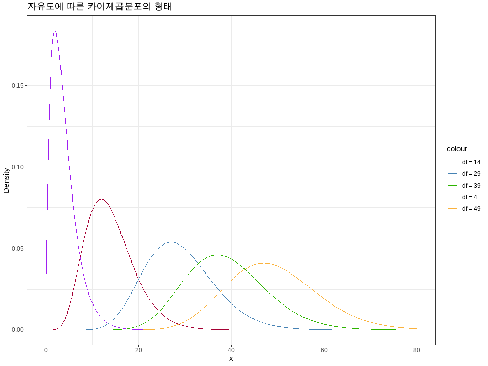

```r
# x 축을 위한 데이터 벡터 생성 (0부터 80까지)
x <- seq(0, 80, by = 0.1)

# 자유도가 4, 15, 29, 39, 49인 카이제곱 분포의 확률밀도함수 계산
y_df1 <- dchisq(x, df = 4)
y_df2 <- dchisq(x, df = 14)
y_df3 <- dchisq(x, df = 29)
y_df5 <- dchisq(x, df = 39)
y_df10 <- dchisq(x, df = 49)

# 데이터 프레임 생성
df <- data.frame(x, y_df1, y_df2, y_df3, y_df5, y_df10)

# 그래프 그리기
ggplot(df, aes(x = x)) +
  geom_line(aes(y = y_df1, color = 'df = 4')) +
  geom_line(aes(y = y_df2, color = 'df = 14')) +
  geom_line(aes(y = y_df3, color = 'df = 29')) +
  geom_line(aes(y = y_df5, color = 'df = 39')) +
  geom_line(aes(y = y_df10, color = 'df = 49')) +
  ggtitle("자유도에 따른 카이제곱분포의 형태") +
  xlab("x") +
  ylab("Density") +
  scale_color_manual(values = c(lre, sbl, ngr, 'purple', lgo)) +
  theme_bw()
```

- 고려 사항
  - 언제 사용하는가?
    - (1)모분산의 통계적 추론
    - (2)범주형 변수의 **독립성/동일성 검정**
  - 분포의 모수는 무엇인가?
    - 표본 크기(n)에 의하여 결정되는 **자유도**
  - 확률 계산하는 R Code

```r
qchisq(0.025, df = 49) #31.6
```

```
## [1] 31.6
```

```r
qchisq(0.975, df = 49) #70.2
```

```
## [1] 70.2
```

### t분포 $t_{\nu}$

- 독립변수 $Z$ 와 $C$ 가 각각 $N(0,1)$, $C \sim \chi^2(v)$ 인 경우를 가정하면,

$$T = \frac{Z}{\sqrt{C/v}}~\sim t(v)$$

- $E(T) = 0$
- $Var(T) = \frac{v}{v-2}, v > 2$
- Why t ?

$$\bar{y} \sim N \left( \mu,
\frac{\sigma^2}{n} \right)$$

$$Z = \frac{\bar{y} -
\mu}{\sqrt{\sigma^2/n}} \sim N(0,1)$$

$$\frac{(n-1)s^2}{\sigma^2}
\sim \chi^2(n-1)$$

따라서,

$$T =
\frac{Z}{\sqrt{\frac{(n-1)s^2}{\sigma^2(n-1)}}} = \frac{\bar{y} -
\mu}{\sqrt{s^2/n}} \approx t(n-1)$$

- t-분포와 정규분포 비교

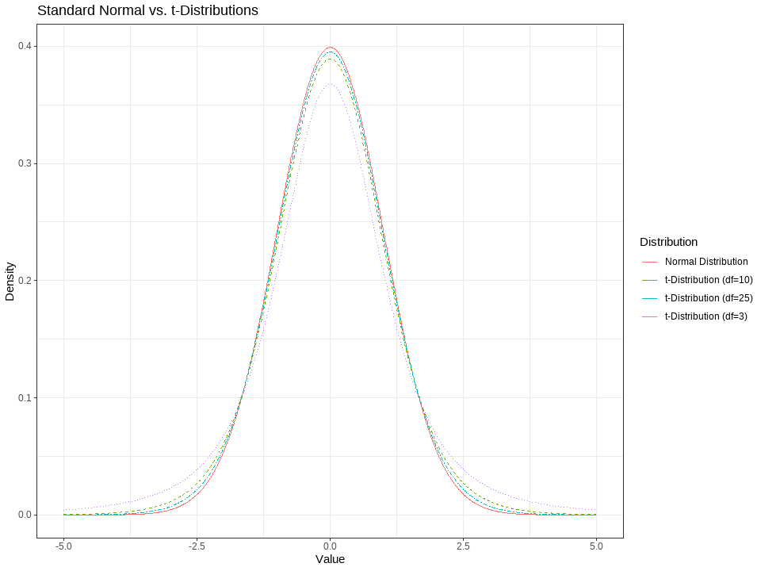

```r
# x 범위 정의
x <- seq(-5, 5, by=0.01)

# 표준 정규 분포
pdf_norm <- dnorm(x, mean=0, sd=1)

# t-분포 (자유도 3, 10, 25)
pdf_t3 <- dt(x, df=3)
pdf_t10 <- dt(x, df=10)
pdf_t25 <- dt(x, df=25)

# 데이터프레임 생성
df <- data.frame(x, pdf_norm, pdf_t10, pdf_t3, pdf_t25)

# 그래프 그리기
ggplot(df, aes(x=x)) +
  geom_line(aes(y=pdf_norm, color='Normal Distribution')) +
  geom_line(aes(y=pdf_t10, color='t-Distribution (df=10)'), linetype="dashed") +
  geom_line(aes(y=pdf_t3, color='t-Distribution (df=3)'), linetype="dotted") +
  geom_line(aes(y=pdf_t25, color='t-Distribution (df=25)'), linetype="twodash") +
  labs(title="Standard Normal vs. t-Distributions",
       x="Value",
       y="Density",
       color="Distribution") +
  theme_bw()
```

- 오른쪽과 왼쪽 꼬리가 두껍다. 정규분포에 비해 변동성 증가한다.
  - why? t분포는 작은 표본 크기에서의 표본 평균의 분포를 설명하기 때문에 이러한 특성을 가진다.
- 고려 사항
  - 언제 사용하는가?
    - 모분산을 모르는 경우, 모평균에 대한 통계적 추론
  - 분포의 모수는 무엇인가?
    - 표본 크기(n)에 의하여 결정되는 **자유도**
  - 확률 계산하는 R Code

```r
qt(0.025, df = 10) # 결과: -2.23
```

```
## [1] -2.23
```

```r
qt(0.025, df = 30) # 결과: -2.04
```

```
## [1] -2.04
```

```r
qnorm(0.025) # 결과: -1.96
```

```
## [1] -1.96
```

```r
qt(0.975, df = 10) # 결과: 2.23
```

```
## [1] 2.23
```

```r
qt(0.975, df = 30) # 결과: 2.04
```

```
## [1] 2.04
```

```r
qnorm(0.975) # 결과: 1.96
```

```
## [1] 1.96
```

- 이를 통해서 n이 커짐에 따라서 정규 분포로 근사하는걸 알 수 있다.

### F분포 $F_{\nu1, \nu2}$

F-분포는 두 개의 자유도 $\nu_1$과 $\nu_2$를 가진 카이제곱 분포의 비율에 대한 분포로 정의된다.

$F = \frac{C/\nu_1}{U/\nu_2}$

$E(F) = \frac{\nu_2}{\nu_2 - 2}, \quad \nu_2 > 2$

$Var(F) = \frac{2\nu_2(\nu_1+\nu_1)}{\nu_1(\nu_2-2)^2(\nu_2-4)}, \quad \nu_2 > 4$

- why F?

$$(n_1 - 1) \frac{s_1^2}{\sigma_1^2} \sim
\chi^2(n_1-1)$$

$$(n_2 - 1) \frac{s_2^2}{\sigma_2^2} \sim
\chi^2(n_2-1)$$

$$F =
\frac{\frac{(n_1-1)s_1^2}{\sigma_1^2} / (n_1 -
1)}{\frac{(n_2-1)s_2^2}{\sigma_2^2} / (n_2 - 1)} =
\frac{s_1^2/\sigma_1^2}{s_2^2/\sigma_2^2} \sim F(n_1-1,
n_2-1)$$

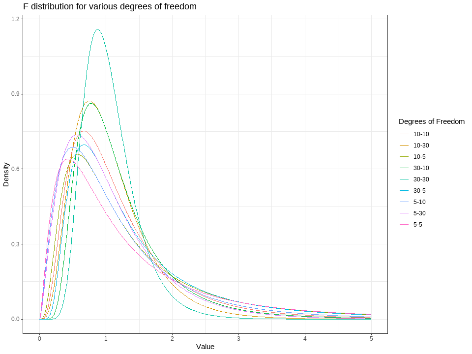

```r
# x 범위 정의
x <- seq(0, 5, by=0.01)

# F 분포 자유도 조합 정의
dfs <- list(c(10,10), c(10,30), c(10,5), c(30,10), c(30,30), c(30,5), c(5,10), c(5,30), c(5,5))

# 각 자유도 조합에 대한 F 분포 계산
pdfs <- lapply(dfs, function(df) df(x, df1=df[1], df2=df[2]))

# 데이터프레임 생성
df_data <- data.frame(x = rep(x, length(dfs)),
                      y = do.call(c, pdfs),
                      df = factor(rep(sapply(dfs, paste, collapse="-"), each=length(x))))

# 그래프 그리기
ggplot(df_data, aes(x=x, y=y, color=df)) +
  geom_line() +
  labs(title="F distribution for various degrees of freedom",
       x="Value",
       y="Density",
       color="Degrees of Freedom") +
  theme_bw()
```

- 고려 사항
  - 언제 사용하는가?
    - (1)모분산의 비에 대한 통계적 추론
    - (2)분산 분석
  - 분포의 모수는 무엇인가?
    - 표본 크기(n)에 의하여 결정되는 **자유도**
  - 확률 계산하는 R Code

```r
qf(0.025, df1 = 5, df2 = 30) #0.161
```

```
## [1] 0.161
```

```r
qf(0.975, df1 = 5, df2 = 30) #3.03
```

```
## [1] 3.03
```

## 1.3. 통계적 추론

Statistical Inference

- 표본 오차가 존재한다면, 이를 의사 결정 과정에 반영할 수 있어야 한다.
- 실무적 고려 사항은 통계적 고려 사항의 전제 조건이다.

### 1.3.1. 구간 추정

Interval Estimation

- 주어진 신뢰도를 만족하는 신뢰구간을 설정하여 미지의 모수 또는 모수들의 함수를 추정하는 방법
  - 95% 신뢰구간을 선택하는 것은 heuristics이다.
  - 표본의 크기가 늘어나면 불확실성이 줄어드는 것이지 참값에 도달한다는 것은 아니다.
    - **표본을 적절하게 설정하는 것이 중요!**

$~~~~~~~~(1-\alpha)100\% \text{ 신뢰구간}$

- 모수(도는 모수의 함수) $\theta$와 이에 대한 추정량 $\hat{\theta}$에 대하여 다음을 만족하는 구간 $[L,~U]$

$~~~~~~~~\Pr(L \leq \theta \leq U) = 1 - \alpha, \ 0 < \alpha < 1$

- 실제 모수는 구해진 신뢰 구간 내에 존재한다.
- 가능하면, 최악의 경우를 고려하여, 신뢰 하한(Lower Limit) 또는 신뢰 상한(Upper Limit) 중의 하나로 해석한다.
- 단일 모평균의 구간 추정
  $$T = \frac{\bar{y} - \mu}{s/\sqrt{n}} \sim t(n-1), s^2 = \frac{1}{n - 1}
  \sum_{i=1}^{n} (y_i - \bar{y})^2$$
- $(1-\alpha)100\% \text{ 신뢰 구간}$

$$\text{Pr} \left[ |T| \leq t_{\alpha/2}(n - 1) \right] = 1-\alpha \\$$

$$\text{Pr} \left[ -t_{\alpha/2}(n - 1) \leq T \leq t_{\alpha/2}(n - 1)
\right] = 1-\alpha \\$$
$$\text{Pr} \left[ -t_{\alpha/2}(n - 1) \leq \frac{\bar{y} -
\mu}{s/\sqrt{n}} \leq t_{\alpha/2}(n - 1) \right] = 1-\alpha \\$$
$$\text{Pr} \left[ \bar{y} - t_{\alpha/2}(n - 1) \frac{s}{\sqrt{n}} \leq
\mu \leq \bar{y} + t_{\alpha/2}(n - 1) \frac{s}{\sqrt{n}} \right] =
1-\alpha \\$$
따라서
$$[L, U] = \left[ \bar{y} - t_{\alpha/2}(n - 1) \frac{s}{\sqrt{n}},
\bar{y} + t_{\alpha/2}(n - 1) \frac{s}{\sqrt{n}} \right]$$

### 1.3.2. 가설 검정

- 증명하고자 하는 주장을 대립 가설로 설정한다.
- (모집단의 특성에 대한) 어떤 주장이나 추측을 가설로 설정하고 표본 관찰을 통하여 **이의 기각(rejection) 여부**를 결정하는 방법
- 통계적 가설
  - 귀무가설 Null Hypothesis: $H_{0}$
    - 기존에 알려진 사실을 구체적으로 표현한 가설
    - 반드시 “=” 포함한다.
  - 대립가설 Alternative Hypothesis: $H_{1}$
    - 분석자가 Data를 통하여 사실임을 입증하고자 하는 가설
- 가설의 종류 양측 vs 단측
  - 성능 향상을 보려는 목적이면 단측이 적합하다.
- 의사결정 오류 Errors of Decision Making
  - 제 1종의 오류$(\alpha)$
    - $H_{0}$가 사실일 때 $H_{0}$를 기각하는 오류
  - 제 2종의 오류$(\beta)$
    - $H_{0}$가 거짓일 때 $H_{0}$를 기각하지 못하는 오류
- 유의수준 Significant level
  - 제 1종의 오류를 범할 확률 허용한계
  - 전통적으로 0.05를 많이 가정한다.
- p-값 p-value
  - $H_{0}$하에서 $H_{0}$를 기각할 최소의 유의 수준
- 의사결정
  - p-value < $\alpha$이면, $H_{0}$를 기각

## 실습 1. 구간 추정 결과의 해석

- 제품간/프로세스간/업무실적간 개선 전/후의 모평균을 비교하고자 한다.
  - 단, 반응값(y)는 큰 값이 바람직하다.
    - 1. 모평균의 차 $\mu1-\mu2$의 95% 신뢰구간이 (-30.5, -10.5)이다.
      - 1. 0이 미포함되었으므로 개선이 되었다.
      - 2. 음수가 되었다는 건 $\mu2$으로 개선이 되었다.($\mu2$평균이 더 높다다)
      - 3. 최소 -10.5 개선되었다. -> **“최악의 경우”**로 봐야 한다.
        - -30.5가 개선되었다고 하면 **과대해석; 과장광고의 느낌**이다.
    - 2. 모평균의 차 $\mu1-\mu2$의 95% 신뢰구간이 (-10.3, 10.7)이다.
      - 1. 0이 포함되었으므로 개선이 되지 않았다고 해석 진행
    - 3. 모평균의 차 $\mu1-\mu2$의 95% 신뢰구간이 (10.7, 30.2)이다.
      - 1. 0이 미포함되었으므로 개선이 되었다.
      - 2. 양수가 되었다는 건 $\mu1$으로 개선이 되었다.
      - 3. 최소 10.7 개선되었다. -> **“최악의 경우”**로 봐야 한다.
    - 따라서 신뢰 구간의 하한을 기준으로 해석하는 것이 합리적인 접근 방식이다.

## 실습 2. 통계적 추론의 응용

- storage.lot.csv
- TU 에너지 저장 장치는 개별 LoT에서 자동 생산된다. 각 LOT에서는 자동 선별 및 측정을 통하여 일정 수를 대상으로 저장 능력을 검증하고 있으며, 검증 횟수는 LOT별로 일정하지 않다.
- 중요 관리 기준은 각 LOT별 제품의 에너지 저장 능력의 평균이며, 만일 LOT의 평균 생산 능력이 985.0보다 작다면, 해당 LOT는 재점 대상이 된다.
- 데이터 불러오기

```r
perform <- read.csv(paste0(data_path, "storage.lot.csv"))
str(perform)
```

```
## 'data.frame':    52000 obs. of  2 variables:
##  $ lot    : int  1 1 1 1 1 1 1 1 1 1 ...
##  $ storage: num  971 827 1041 1236 1028 ...
```

- 데이터 시각화

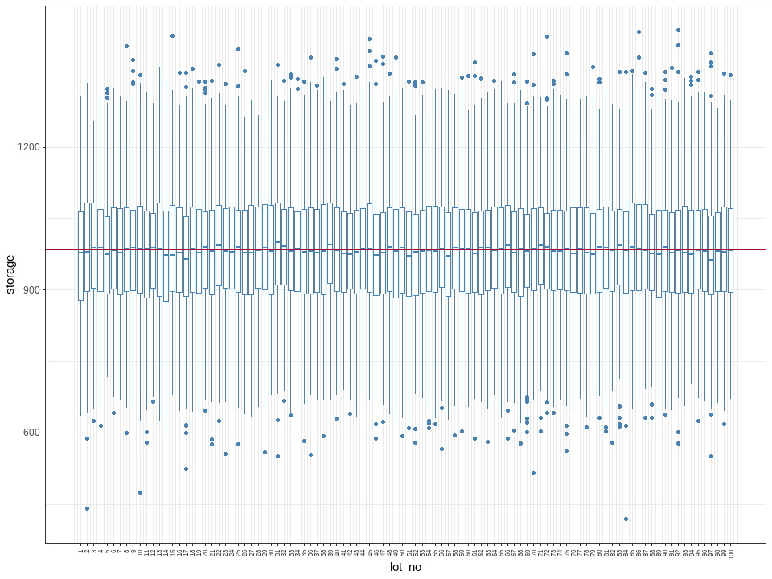

```r
limit <- 985

perform %>%
  ggplot(aes(x = lot, y = storage, group = lot)) +
  geom_boxplot(position = position_dodge(width = 0.8), color = sbl) +
    labs(x = "lot_no", y = "storage") +
    geom_hline(yintercept = limit, color = lre) +
    scale_x_continuous(breaks=seq(1, 100, 1)) +
    theme_bw() +
    theme(axis.text.x = element_text(angle = 90, vjust = 0.5, hjust = 1)) +
    theme(axis.text.x = element_text(size = 6))
```

- lot별로 요약이 필요해보인다.
  - 재점검 판단이 불가능하다.
- 데이터 요약1

```r
p_sum <- perform %>%
  group_by(lot) %>%
  summarize(lmean = mean(storage), lsd = sd(storage))

head(p_sum, 3)
```

```
## # A tibble: 3 × 3
##     lot lmean   lsd
##   <int> <dbl> <dbl>
## 1     1  971.  128.
## 2     2  984.  132.
## 3     3  989.  120.
```

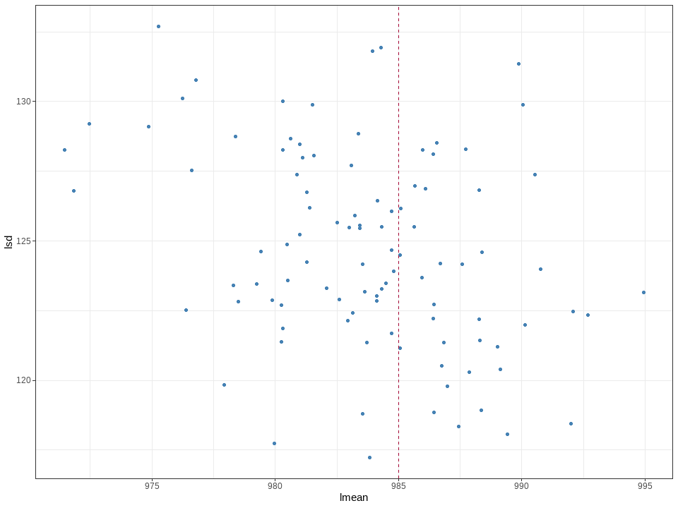

```r
p_sum %>% ggplot(aes(lmean, lsd)) +
  geom_point(color = sbl) +
  geom_vline(xintercept = 985, color = lre, linetype = "dashed") +
  theme_bw()
```

- 이렇게 표현을 하게 되면 대부분의 lot가 985.0보다 작아 재점검 대상이 된다.
  - 의미가 없는 시각화이다.
  - 따라서 각 “lot”의 평균값의 신뢰구간을 표현하여 다시 분석을 실시한다.
- 데이터 요약2: 95% 신뢰구간

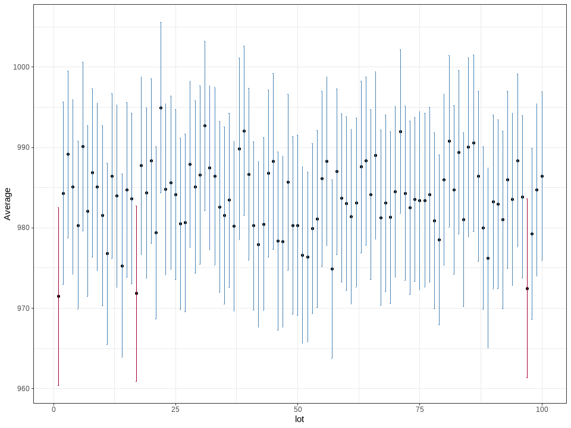

```r
perform_c <- perform %>%
  group_by(lot) %>%
  summarize(
    avg = mean(storage),
    lower = mean(storage) - qt(0.975, n() - 1) * (sd(storage) / sqrt(n())),
    upper = mean(storage) + qt(0.975, n() - 1) * (sd(storage) / sqrt(n()))
  ) %>%
  ungroup()

perform_c <- as.data.frame(perform_c)

perform_c %>%
  ggplot(aes(x = lot, y = avg)) +
  geom_point() +
  geom_errorbar(aes(ymin = lower, ymax = upper, color = ifelse(upper < 985, "A", "B")), width = 0.2) +
  scale_color_manual(values = c("A" = lre, "B" = sbl)) +
  guides(color = FALSE) +
  labs(x = "lot", y = "Average") +
  theme_bw()
```

- 대부분의 “lot”는 평균값 주변에 데이터가 밀집되어 있어 변동성이 크지 않아 보인다.
- 빨간색 바로 표시되는 “lot”는 상한값이 985.0보다 작은 것을 의미한다.
- 따라서3개의 “lot”가 관리 기준을 만족하지 못하는 것으로 파악이 된다.
  - 재점검 실시

# 2. 확률 분포와 그 응용

- 확률 이론은 계산으로 축소된 상식일 뿐이다.
- 다음 세가지를 고민하면서 접근해야 어떤 문제를 맞닿았을 때 고민을 해보고 적용할 수 있다.
  - 언제 사용하는가?
    - 해당 확률 분포나 방법이 적절한 상황을 판단하는데 중요하다.
  - 확률 분포를 결정하는 모수(들)은 무엇인가?
  - 관심 사상에 대한 확률을 어떻게 계산할 것인가?
- 실무적 관심 특성에 대한 중요 확률 분포

| 분포 유형 | 분포 이름 | 모수 | R 함수 | 기호 |
| --- | --- | --- | --- | --- |
| 이산형 | 이항 Binomial | n, p | `binom()` | $Bin(n, p)$ |
|  | 포아송 Poisson | $\lambda$ | `pois()` | $Poi(\lambda)$ |
| 연속형 | 정규 Normal | $\mu, \sigma^2$ | `norm()` | $N(\mu, \sigma^2)$ |

- R에서 쓰는 확률 분포 함수들 의미:
  $$d*: \text{확률 밀도(질량) 함수 probability mass(density) function }
  p(\theta) = f(y; \theta) \\
  p*: \text{누적 분포 함수 cumulative distribution function } F(y) = Pr(Y
  \leq y) \\
  q*: \text{역 누적 분포 함수 inverse cumulative distribution function }
  F^{-1}(p) = \inf\{z : F(z) \geq p\} \\
  r*: \text{랜덤 숫자 생성 함수 random number generation function } r_1,
  r_2, ... r_n \sim iid \ p(\theta) \\$$

## 2.1. 이산형 확률 분포

- 유한 또는 가변 값을 취할 수 있는 확률변수의 확률 분포
- 일정 단위에서 특정 범주의 **빈도**를 수집하는 경우 유용하다.
- 개별 비율 vs 누적 비율
  - 누적 비율로 봐야 한다. -> **비율은 누적**한다.

### 2.1.1. 이항 분포

Binomial Distribution

- $Y$ ~ $Bin(n,p)$
- 조건 및 특성:
  - 베르누이 시행을 $n > 1$ 번 독립적으로 시행했을 때 특정 사건의 수
  - 특정 모비율 $p$을 갖는 (무한)모집단으로부터 추출한 단위 표본(n) 중 관심 사건의 수
  - n 번의 시행에서 매회 성공률이 p, $0 < p < 1$로 동일함을 가정
- 확률(질량) 함수:

$$f(y) = \binom{n}{y} p^y (1-p)^{n-y}, y = 0,1,2,..., n$$

- 평균: $E(Y) = np$
- 분산: $Var(Y) = np(1 - p)$
- 분산은 평균의 함수이다.

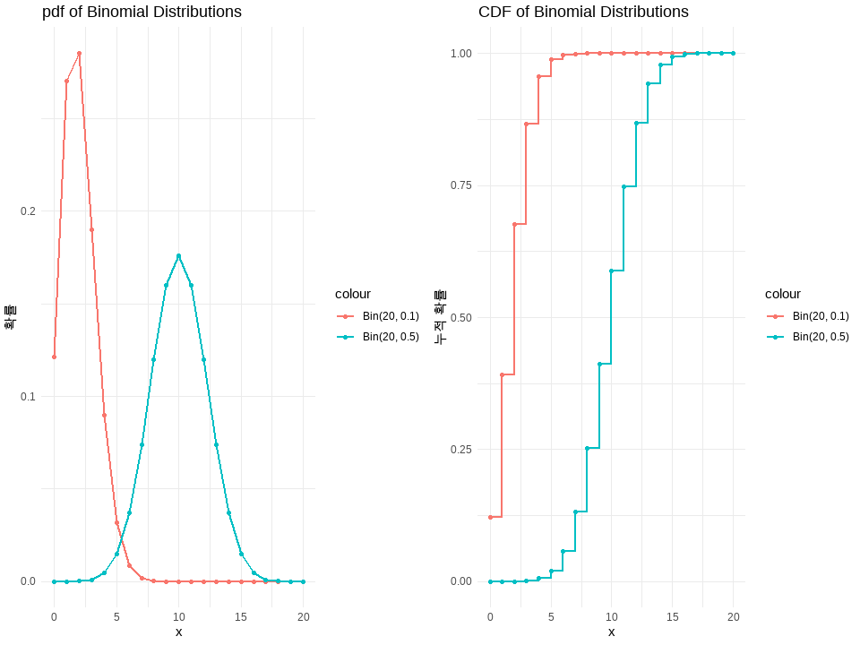

```r
# Binomial 분포의 데이터 생성
x <- 0:20
y1 <- dbinom(x, 20, 0.1) # Bin(20, 0.1)의 pdf
y2 <- dbinom(x, 20, 0.5) # Bin(20, 0.5)의 pdf

y1_cdf <- pbinom(x, 20, 0.1) # Bin(20, 0.1)의 CDF
y2_cdf <- pbinom(x, 20, 0.5) # Bin(20, 0.5)의 CDF

data_pdf <- data.frame(x, y1, y2)
data_cdf <- data.frame(x, y1_cdf, y2_cdf)

# pdf plot
pdf_plot <- ggplot(data_pdf, aes(x = x)) +
  geom_line(aes(y = y1, color = "Bin(20, 0.1)"), size = 1) +
  geom_point(aes(y = y1, color = "Bin(20, 0.1)")) +
  geom_line(aes(y = y2, color = "Bin(20, 0.5)"), size = 1) +
  geom_point(aes(y = y2, color = "Bin(20, 0.5)")) +
  labs(title = "pdf of Binomial Distributions", y = "확률", x = "x") +
  theme_minimal()
# cdf plot
cdf_plot <- ggplot(data_cdf, aes(x = x)) +
  geom_step(aes(y = y1_cdf, color = "Bin(20, 0.1)"), size = 1) +
  geom_point(aes(y = y1_cdf, color = "Bin(20, 0.1)")) +
  geom_step(aes(y = y2_cdf, color = "Bin(20, 0.5)"), size = 1) +
  geom_point(aes(y = y2_cdf, color = "Bin(20, 0.5)")) +
  labs(title = "CDF of Binomial Distributions", y = "누적 확률", x = "x") +
  theme_minimal()

#
gridExtra::grid.arrange(pdf_plot, cdf_plot, ncol = 2)
```

- Bin(20, 0.1) vs Bin(20, 0.5)
  - 빨간색 선은 성공확률의 0.1인 20번의 시도에 대한 분포이다. 0~5사이에 집중되어 있다.
    - 따라서 20번의 시도중에서 0~5번 성공할 확률이 높다는 것을 알 수 있다.
  - 파란색 선은 성공확률의 0.5인 20번의 시도에 대한 분포이다. 10 근처에서 가장 높을 값을 가진다.
    - 즉, 20번의 시도 끝에 10번 성공할 확률이 가장 높음을 의미한다.
  - 누적 확률을 확인해봐도 앞서 봤던 결과처럼 빨간색선은 x = 5일때 누적확률이 거의 1에 가까워지는 것을 알 수 있다.

### 2.1.2. 포아송 분포

Poisson Distribution

- $Y$ ~ $Poi(\lambda)$
- 확률 (질량)함수:
  $$f(y) =
  \frac{\lambda^y e^{-\lambda}}{y!}$$
  여기서, $y = 0, 1, 2, ...$
- 기대값: $E(Y) = \lambda$
- 분산: $Var(Y) = \lambda$
- $Y_i \sim Poi(\lambda_i), i = 1, 2, ..., k$

$$\sum_{i=1}^{k} Y_i \sim
Poi(\sum_{i=1}^{k} \lambda_i)$$

- 분산은 평균의 함수이다.

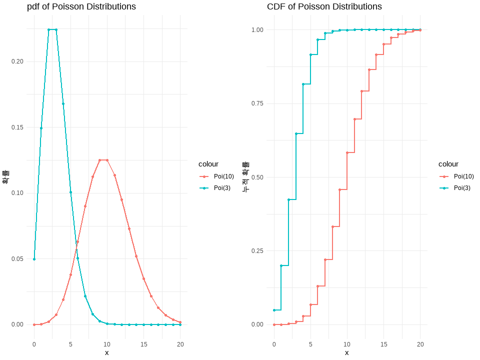

```r
# 포아송 분포의 데이터 생성
x <- 0:20
y1 <- dpois(x, 3) # Poi(3)의 pdf
y2 <- dpois(x, 10) # Poi(10)의 pdf

y1_cdf <- ppois(x, 3) # Poi(3)의 CDF
y2_cdf <- ppois(x, 10) # Poi(10)의 CDF

data_pdf <- data.frame(x, y1, y2)
data_cdf <- data.frame(x, y1_cdf, y2_cdf)

# pdf plot
pdf_plot <- ggplot(data_pdf, aes(x = x)) +
  geom_line(aes(y = y1, color = "Poi(3)"), size = 1) +
  geom_point(aes(y = y1, color = "Poi(3)")) +
  geom_line(aes(y = y2, color = "Poi(10)"), size = 1) +
  geom_point(aes(y = y2, color = "Poi(10)")) +
  labs(title = "pdf of Poisson Distributions", y = "확률", x = "x") +
  theme_minimal()

# cdf plot
cdf_plot <- ggplot(data_cdf, aes(x = x)) +
  geom_step(aes(y = y1_cdf, color = "Poi(3)"), size = 1) +
  geom_point(aes(y = y1_cdf, color = "Poi(3)")) +
  geom_step(aes(y = y2_cdf, color = "Poi(10)"), size = 1) +
  geom_point(aes(y = y2_cdf, color = "Poi(10)")) +
  labs(title = "CDF of Poisson Distributions", y = "누적 확률", x = "x") +
  theme_minimal()

#
gridExtra::grid.arrange(pdf_plot, cdf_plot, ncol = 2)
```

- 각각 사건의수가 3일때와 10일 때의 부근에서 많이 일어난 것을 알 수 있다.

## 2.2. 연속형 확률 분포

- 연속형 확률 변수
  - 임의의 구간 또는 구간들의 합을 취할 수 있는 확률 변수
  - 구간/비율 척도로 측정되며, 유무형의 측정 장비에 의하여 확인이 가능
  - 측정 장비를 적용하는 경우, 고유의 측정 단위 존재
- 연속형 확률 분포를 결정하는 요소
  - 기술적: 관심 특성의 기술적 특징
  - 환경적: 데이터의 측정 환경
  - 상식적: 실무 현상에 대한 객관성과 타당성
- 연속형 확률 분포는 **형태(shape), 위치(location), 척도(scale)**에 의하여 결정
- 연속형 확률밀도 함수
  - 모든 가능한 y값에 대하여 확률 밀도 값은 0보다 크거나 같다.
  - 모든 가능한 y값에서 구한 면적은 1이다.
  - 관심 사상이 정의된 구간의 면적으로 해당 확률을 계산한다.

### 2.2.1. 정규분포 $Y$ ~ $N(\mu,\sigma^2)$

Normal Distributions

- 언제 사용하는가?
  - 구간/비율 척도로 측정되는 프로세스의 관심 특성에 대한 특징 파악
  - 좌우대칭, 종형의 형태를 갖는 경우
  - 제조 현장에서 목표값/참값이 명확하고 우연 변동(White Noise)만 존재하는 경우
- 정규 분포의 모수(들)는 무엇인가?
  - $\mu: 모평균$
  - $\sigma^2:~분산(\sigma:~표준편차)$
- 정규 분포의 유용성
  - **형태**, 좌우대칭,종형: 이상 원인(Special Cause)의 유무를 확인
  - **위치**, 평균: 목표값의 달성 여부 확인
  - **척도**, 분산/표준편차: 프로세스 관리 기술 수준에 대한 정보 제공
    - 분산/표준편차가 크다면, 관리 기술 수준이 낮은 것이다.
- 정규 분포의 표준화
  - 모든 정규 분포는 표준화를 통하여 표준 정규 분포로 변환될 수 있다.
  - 표준화의 장점
    - 1. 표준 정규 분포를 이용한 확률 계산 용이
    - 2. 서로 다른 측정 단위 또는 산포를 갖는 특성의 비교

$~~~~~~~~~~~~~~~~Y$ ~ $N(\mu,\sigma^2)이면,~~Z=\frac{Y-\mu}{\sigma}$~$N(0,1)$

## 실습 3. 이항 분포를 이용한 확률 계산

- 지난 분기 개발 업무(A)의 일정 미준수율은 약 20%정도이고 검증 업무 (B)의 시간 미준수율은 약 10%정도이다. 차기 분기 이전에 각각의 업무에서 임의로 선택된 30건에 대한 미준수 건수를 조사하여 개선 프로세스 도입 여부를 판단하고자 한다. (A)와 (B) 각 업무에 대하여 다음을 계산하시오.
  - 30건 중에서 미준수가 1건도 없을 확률
    - (A)의 경우: $P(X=0) = \binom{30}{0} (0.2)^0 (0.8)^{30}$
    - (B)의 경우: $P(X=0) = \binom{30}{0} (0.1)^0 (0.9)^{30}$
  - 30건 중에서 미준수가 6건 이상 발생할 확률
    - (A)의 경우: $1-(P(X=0)+P(X=1), ..., +P(X=5))$
    - (B)의 경우: $1-(P(X=0)+P(X=1), ..., +P(X=5))$
  - 미준수 건수가 4건 이상일 확률이 50%를 넘지 않는다면 현재 프로세스를 유지하고, 만일 50%를 넘는다면 새로운 관리 기준을 도입하려 한다. 두 업무는 새로운 프로세스를 도입해야 하는가 여부를 결정하시오.
    - (A)의 경우: $1-(P(X=0)+P(X=1), ..., +P(X=3))$
    - (B)의 경우: $1-(P(X=0)+P(X=1), ..., +P(X=3))$
- R코드로 판단 기준 정보 확인 진행

```r
n <- 30
pa <- 0.2
pb <- 0.1

# 1. 30건 중에서 미준수가 1건도 없을 확률
c(pbinom(0, n, pa), pbinom(0, n, pb))
```

```
## [1] 0.00124 0.04239
```

```r
# 2. 30건 중에서 미준수가 6건 이상 발생할 확률
c(1-pbinom(5, n, pa), 1-pbinom(5, n, pb))
```

```
## [1] 0.5725 0.0732
```

```r
# 3. 미준수 건수가 4건 이상일 확률이 50%를 넘지 않는다면 현재 프로세스를 유지
c(1-pbinom(3, n, pa), 1-pbinom(3, n, pb))
```

```
## [1] 0.877 0.353
```

## 실습 4. 포아송 분포를 이용한 확률 계산

- recognition.test.csv
- 카메라의 인식 성능을 조사하기 위하여 78종류의 대상들에 대하여 반복 인식 시험을 실시하였다. 이는 주어진 사진 또는 사물을 촬영한 후 고유의 알고리즘을 통하여 인식된 대상을 구별한다. 각 대상을 올바로 분류하지 못하는 경우를 결함으로 정의하였다. 자동화 Test인 관계로 정확한 시행 횟수는 측정하지 않았으며, 인식 대상에 따라 약 3500 ~ 3600번 정도 진행된다. 실제 제품에서는 대상이 모호한 경우, 재측정을 2회 진행한다. 각 대상에서 결함이 2회 이하로 발생활 확류을 구하고, 어떤 대상들의 결함이 심각한지를 확인하시오.
- 데이터 불러오기

```r
test <- read.csv(paste0(data_path, "recognition.test.csv"))
str(test)
```

```
## 'data.frame':    78 obs. of  32 variables:
##  $ id      : chr  "t142" "m156" "h106" "p147" ...
##  $ defect1 : int  9 9 4 7 5 10 1 9 9 7 ...
##  $ defect2 : int  8 3 4 1 9 9 8 7 2 4 ...
##  $ defect3 : int  2 7 4 6 6 3 9 7 4 2 ...
##  $ defect4 : int  1 8 7 9 5 4 9 9 1 6 ...
##  $ defect5 : int  1 9 5 10 9 3 9 10 2 2 ...
##  $ defect6 : int  7 1 5 3 7 9 6 9 8 8 ...
##  $ defect7 : int  10 10 9 5 8 1 7 6 5 7 ...
##  $ defect8 : int  9 10 7 10 4 9 2 2 10 8 ...
##  $ defect9 : int  3 2 9 2 6 3 2 2 4 7 ...
##  $ defect10: int  6 2 6 6 7 1 4 7 10 2 ...
##  $ defect11: int  9 5 4 8 2 2 6 5 6 10 ...
##  $ defect12: int  9 4 3 6 5 8 6 4 3 5 ...
##  $ defect13: int  3 9 10 9 2 2 10 10 2 5 ...
```

[output cut: 18 more lines]

- defect1 ~ defect30로 30개의 결함에서 해당 대상들에 대해 해당 결함이 몇 번 발생했는지 파악할 수 있다.
- 결함율 계산 및 시각화

```r
test <- test %>%
  mutate(id = fct_reorder(id, mean),
         success_p = ppois(2, mean))
str(test)
```

```
## 'data.frame':    78 obs. of  33 variables:
##  $ id       : Factor w/ 78 levels "m48","m80","p114",..: 48 71 58 68 6 38 30 72 11 44 ...
##  $ defect1  : int  9 9 4 7 5 10 1 9 9 7 ...
##  $ defect2  : int  8 3 4 1 9 9 8 7 2 4 ...
##  $ defect3  : int  2 7 4 6 6 3 9 7 4 2 ...
##  $ defect4  : int  1 8 7 9 5 4 9 9 1 6 ...
##  $ defect5  : int  1 9 5 10 9 3 9 10 2 2 ...
##  $ defect6  : int  7 1 5 3 7 9 6 9 8 8 ...
##  $ defect7  : int  10 10 9 5 8 1 7 6 5 7 ...
##  $ defect8  : int  9 10 7 10 4 9 2 2 10 8 ...
##  $ defect9  : int  3 2 9 2 6 3 2 2 4 7 ...
##  $ defect10 : int  6 2 6 6 7 1 4 7 10 2 ...
##  $ defect11 : int  9 5 4 8 2 2 6 5 6 10 ...
##  $ defect12 : int  9 4 3 6 5 8 6 4 3 5 ...
##  $ defect13 : int  3 9 10 9 2 2 10 10 2 5 ...
```

[output cut: 19 more lines]

- 각 대상의 결함들의 mean값과, 조건(**각 대상에서 결함이 2회 이하로 발생**)을 만족하는 확률을 구했다.

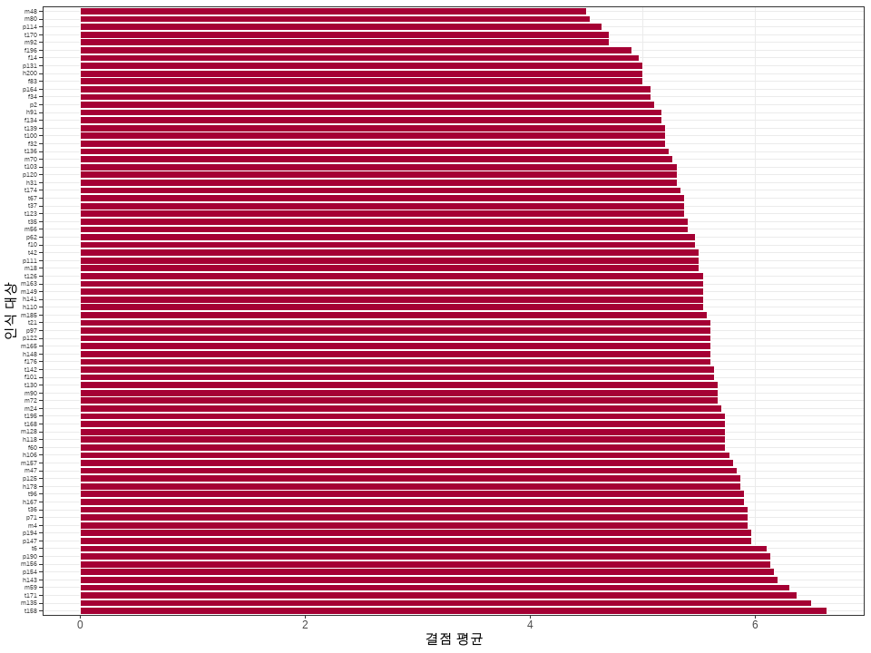

```r
test %>% ggplot(aes(x = fct_reorder(id, -mean),
                    y = mean)) +
  geom_bar(stat = "identity",
           color = "white", fill = lre) +
  labs(x = "인식 대상", y = "결점 평균") +
  coord_flip() +
  theme_bw() +
  theme(axis.text.y = element_text(size = 5))
```

- 먼저, 결점 평균 그래프를 보면, 몇몇 대상에서는 평균 결점이 6번 이상으로 높게 나타나는 것을 볼 수 있다.
- 이런 대상들은 카메라의 인식 성능이 낮아 개선이 필요해 보인다.
- 다음으로는 각 대상에서 결함이 2회 이하로 발생할 확률에 대한 그래프를 살펴 본다.

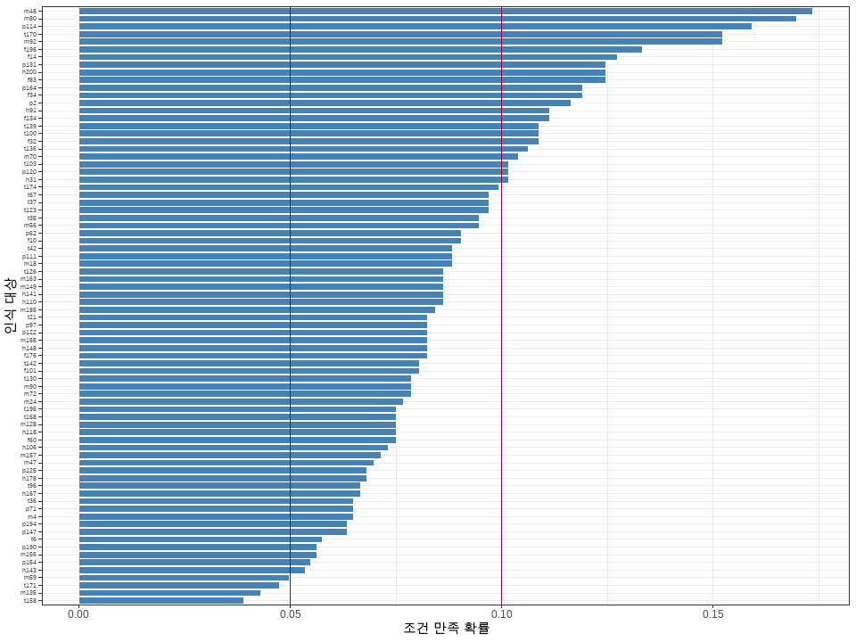

```r
test %>% ggplot(aes(x = fct_reorder(id, success_p),
                    y = success_p)) +
  geom_bar(stat = "identity",
           color = "white", fill = sbl) +
  geom_hline(yintercept = 0.05, color = lre) +
  geom_hline(yintercept = 0.10, color = lre) +
  labs(x = "인식 대상", y = "조건 만족 확률") +
  coord_flip() +
  theme_bw() +
  theme(axis.text.y = element_text(size = 5))
```

```r
over_10_percent_ids <- test %>%
  filter(success_p > 0.10) %>%
  pull(id)

print(over_10_percent_ids)
```

```
##  [1] f196 f34  t100 m80  t136 p114 f134 t170 p131 h31  m48  m92  h200
## [14] t139 f83  p2   f32  m70  p120 t103 f14  p164 h91
## 78 Levels: m48 m80 p114 m92 t170 f196 f14 f83 h200 p131 f34 p164 ... t158
```

- 파악한 결과, f196 f34 t100 m80 t136 p114 f134 t170 p131 h31 m48 m92 h200 t139 f83 p2 f32 m70 p120 t103 f14 p164 h91 으로 나타났다.
- 추가적으로 해당 대상들에서 어떤 결함이 많이 발생하는지 파악을 해보았다.

```r
# 10% 이상의 success_p 값을 가지는 ID들을 필터링
high_defect_ids <- test[test$success_p > 0.10,]

# 10% 이상의 success_p 값을 가지는 데이터의 각 결함의 평균 값을 계산
avg_defects <- colMeans(high_defect_ids[,c('defect1', 'defect2', 'defect3', 'defect4', 'defect5', 'defect6', 'defect7', 'defect8', 'defect9', 'defect10', 'defect11', 'defect12', 'defect13', 'defect14', 'defect15', 'defect16', 'defect17', 'defect18', 'defect19', 'defect20', 'defect21', 'defect22', 'defect23', 'defect24', 'defect25', 'defect26', 'defect27', 'defect28', 'defect29', 'defect30')]) %>%
  sort(decreasing = TRUE)

print(avg_defects)
```

```
## defect29  defect8 defect20  defect6  defect5 defect24 defect16 defect25
##     7.17     5.96     5.96     5.87     5.78     5.65     5.52     5.35
##  defect1 defect18  defect7  defect2 defect11 defect28  defect4 defect10
##     5.13     5.09     4.96     4.91     4.87     4.87     4.78     4.78
## defect19  defect3 defect27 defect30 defect14  defect9 defect13 defect21
##     4.78     4.74     4.74     4.70     4.65     4.61     4.61     4.61
## defect22 defect17 defect26 defect15 defect23 defect12
##     4.57     4.52     4.52     4.43     4.43     4.09
```

```r
# 가장 높은 결함 값 파악
```

[output not shown]

- 많이 발생한 결함과 대상을 가지고 품질을 위해 다시 노력을 하면 좋은 결과를 볼 수 있을 것이다.

## 실습 5. 서로 다른 난이도의 비교

- 김열공 학생은 00자격 시험에 2번 응시하였다. 1차 응시에서는 270/320점을 획득하였고, 2차 시험에서는 290/320점을 획득하였다. 원하는 300/320점을 획득하지는 못했지만 시험 성적이 높아지고 있으니 곧 300점을 넘을 수 있을 것이라고 생각하고 있다. 1차 시험을 치른 전체 학생들의 점수는 $N(250, 10^2)$을 따르며 2차 시험을 치른 전체 학생들의 점수는 $N(270, 15^2)$을 따른다. 김철수 학생은 실제로 어떤 시험을 더 잘 보았는가?
- 의사 결정 기준값 계산

```r
mu1 <- 250
mu2 <- 270
sigma1 <- 10
sigma2 <- 15
c(pnorm(270, mu1, sigma1), pnorm(290, mu2, sigma2))
```

```
## [1] 0.977 0.909
```

- 각각 270점, 290점 이하의 점수를 얻을 확률을 의미를 한다.

```r
c(1-pnorm(270, mu1, sigma1), 1-pnorm(290, mu2, sigma2))
```

```
## [1] 0.0228 0.0912
```

- 방금 계산한 값에서 1을 뺌으로써 해당 점수보다 높은 점수를 얻을 확률을 구한다.
- 결과의 시각화

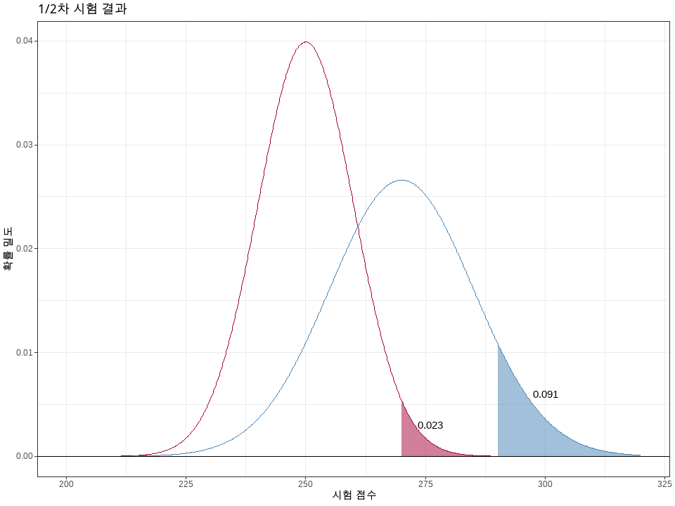

```r
prob1 <- 1-pnorm(270, mu1, sigma1)
prob2 <- 1-pnorm(290, mu2, sigma2)
#
x <- seq(200, 320, length.out = 1000)
y1 <- dnorm(x, mu1, sigma1)
y2 <- dnorm(x, mu2, sigma2)
df <- data.frame(x, y1, y2)
#
ggplot(df, aes(x, y1)) +
  geom_line(color = lre) +
  geom_ribbon(data = subset(df, x > 270),
              aes(ymax = y1), ymin = 0, fill = lre,
              alpha = 0.5) +
  geom_line(aes(x, y2), color = sbl) +
  geom_ribbon(data = subset(df, x > 290),
              aes(ymax = y2), ymin = 0, fill = sbl,
              alpha = 0.5) +
  geom_hline(yintercept = 0) +
  labs(title = "1/2차 시험 결과", x = "시험 점수",
       y = "확률 밀도") +
  theme_bw() +
  annotate("text", x = 276, y = 0.003,
           label = round(prob1, 3)) +
  annotate("text", x = 300, y = 0.006,
           label = round(prob2, 3))
```

- 1차 시험은 0.0228, 2차 시험은 0.0912이다.
- 성적의 퍼진 정도를 파악을 해보면 1차 시험은 붉은색 곡선이 더 뾰족한 것으로 보아, 학생들의 성적이 더 밀집되어 있는 것을 알 수 있다.
- 2차 시험은 파란색 곡선이 빨간색 곡선보다 완만한 것으로 보아, 성적이 더 넓게 퍼져있다는 걸 알 수 있다.
- 2차 시험에서 점수 자체는 높았지만 난이도가 1차 시험에 비해 쉬웠다고 볼 수 있다.
  - 아니면 대체로 많은 학생들의 1차 시험에 비해 공부를 많이하여 시험 성적이 이전보다 향샹했다고 볼 수도 있다.
- 따라서 1차 시험에서는 상위 0.0228(약 2%), 2차 시험에서는 상위 0.0912(약 9%)로 김철수 학생은 실제로 1차 시험에서 더 잘 봤다고 할 수 있다.

## 실습 6. 서로 다른 단위의 실행력 비교

- A 업무는 처리 시간(분)이 중요 특성이며 이는 $N(30, 3^2)$을 따른다. 또한 만일 처리 시간이 35분을 넘는 경우 고객 불만족이 발생하는 것으로 알려져 있다.
- B 업무는 불순물의 정제량(g)이 중요 특성이며 이는 $N(200, 25^2)$을 따른다. 또한 정제량이 150g보다 적은 경우 고객 불만족이 발생하는 것으로 알려져 있다.
- A 업무와 B 업무 중에서 어느 업무가 고객 불만족을 유발 할 가능성이 높은가?
- 의사 결정 기준값 계산

```r
mu1 <- 30
mu2 <- 200
sigma1 <- 3
sigma2 <- 25
c(1-pnorm(35, mu1, sigma1), pnorm(150, mu2, sigma2))
```

```
## [1] 0.0478 0.0228
```

- 고객 불만족 기준에 따라서 고객 불만족 가능성을 계산을 해보았다.
- A 업무의 고객 불만족 확률: 0.0478 (즉, 4.78%)
- B 업무의 고객 불만족 확률: 0.0228 (즉, 2.28%)
  - A 업무에서 처리 시간이 35분을 넘는 경우에 고객 불만족이 발생할 확률은 4.78%이다.
  - 반면 B 업무에서 정제량이 150g보다 적을 때 고객 불만족이 발생할 확률은 2.28%으로 나타났다.
  - A업무의 고객 불만족 확률이 B 업무보다 높다고 할 수 있다.
  - 따라서 A 업무가 고객 불만족을 유발 할 가능성이 더 높다.

# 3. 확증적 비교 방법

Confirmatory Comparisons

- 프로세스란 제품/서비스 결과물의 모임이 아니라 요소와 절차의 모임이다.
- 주어진 목적과 데이터의 유형에 따라 적절한 분석 방법을 선택해야 한다.
- 통계적 비교 방법의 유용성은 **통계적 가정을 만족**한다는 전제 하에서 보장되는 것이다.

|  | Continuous Data | Categorical Data |
| --- | --- | --- |
| 1 집단 | 1-sample t | 1-proportion |
| 2 집단 | 2-sample t | 2-proportions |
| 2 집단 쌍체 | Paired t | McNemar’s Test |
| 2 집단 이상 | ANOVA | Chi-square Test |

- 범주형 데이터
  - 집계/측정 단위 선택
  - 범주 결정 빈도 집계
- -> 이산형 Discrete Data

## 3.1. 범주형/이산형 데이터를 이용한 비교

- MECE
  - Mutually&Exclusive: Distinctly Different 겹치지 말고
  - Collectively&Exhaustive: All Together, Make a Complete Whole 빠트리지 말고
  - 쉽게 생각하면 짜장면, 짬뽕, 국수??…. -> MECE 실패

### 3.1.1. 모비율의 비교1

- 단일 모비율
  - **stats::prop.test(x, n, p, alternative = c(“less”, “greater”, “two sided”))**
- 두 집단의 모비율 비교
  - **stats::prop.test(x, y, n, p, alternative = c(“less”, “greater”, “two.sided”))**

### 3.1.2. 모비율의 비교2

- 교차표 Contingency Table
  - 2개 이상의 변수들의 빈도 분포를 표현하는 행렬 형식의 표
  - 이항, 포아송, 다항 분포를 따르는 이산형 데이터의 요약에 유용
- 쌍체 집단의 모비율 비교 McNemar’s Test

| Group/Results | Go | NoGo | Total |
| --- | --- | --- | --- |
| Go | p11 | p12 | p1+ |
| NoGo | p21 | p22 | p2+ |
| Total | p+1 | p+2 | p++ |

| Group/Results | Go | NoGo | Total |
| --- | --- | --- | --- |
| Go | n11 | n12 | n1+ |
| NoGo | n21 | n22 | n2+ |
| Total | n+1 | n+2 | n++ |

$H_0 : p1+ - p+1 = 0$ vs $H_1 : p1+ - p+1 ≠ 0$

주어진 유의수준 알파에서 다음을 만족하면 $H_0$을 기각한다.

$χ^2_M = \frac{(|n12 - n21| - 1)^2}{n12 + n21}$ $χ^2_M > χ^2_{(1,α)}$ 또는
$$p-value < α$$

- 독립성/동질성 검정 Independent Test

**H₀**: Independence $p_{ij} = p_{i+}p_{+j}$ vs. $H₁$: not $H₀$

- 카이 제곱 통계량

$$\chi^2 =
\sum_{i=1}^{r}\sum_{j=1}^{c}\frac{(O_{ij} - E_{ij})^2}{E_{ij}} \sim
\chi^2_{(r-1)(c-1)}$$

$$여기서~~~E_{ij} =
\frac{n_{i+}n_{+j}}{n_{++}}$$

- Pearson’s Residuals

$$r_{ij} = \frac{O_{ij} -
E_{ij}}{\sqrt{E_{ij}}}, \forall i,j$$

## 3.2. 연속형 데이터를 이용한 비교

### 3.2.1. 정규성 검정

Normality Test

- 목적
  - 선택된 표본이 정규분포로부터 랜덤하게 선택되었는가 여부를 확인
- 가설
  - $H_{0}$: 데이터는 정규분포를 따른다.
- 의사결정
  - p-value < $\alpha$이면, $H_{0}$를 기각
- 정규성이 위배가 되면?
  - 평균이 올바른 대표값이 될 수 없다.
  - 정규성을 만족하는 경우와 비교할 때, 표준편차는 커지는 경향을 가진다.
- **표본 크기가 작은 경우, 정규성은 거의 위배되지 않는다.**
- 샘플 사이즈가 많다고 정규성이 위배되는 것은 아니다.

### 3.2.2. 단일 집단 모평균 비교

1-sample t Test

- 목적
  - 모집단의 평균$(\mu)$과 기준값$(\mu_{0})$의 차이 유무 및 대소 관계의 검증증
- 가설
  - 방향성 / 단측 가설
  - 비방향성 / 양측 가설
- 의사결정
  - p-value < $\alpha$이면, $H_{0}$를 기각
- 기준값$(\mu_0)$은 명확한 근거 하에서 지정되어야 한다.
  - ex) 고객의 요구 사항, 장기간 수집된 제품 특성값 평균
- 모집단의 정규성이 위배되는 경우, 검정 결과는 근사적 결과이다.

### 3.2.3. 상호 독립인 두 집단 모평균 비교

2-sample t Test

- 목적
  - 상호 독립인 두 집단의 모평균 비교
- 가설
  - 단측/방향설 가설
  - 비방향성/양측가설
- 의사 결정
  - p-value < $\alpha$이면, $H_0$를 기각한다.
- 가능한 한 두 집단의 표본 크기는 동일하게 고려한다.
- 두 집단의 등분산성이 위배되는 경우에는 근사 검정을 적용한다.

### 3.2.4. 쌍체 집단 차이의 모평균 비교

paired-t Test

- 목적
  - 각 개체별로 반복 측정된 차이(difference)를 이용하여 두 집단 간 차이의 모평균 확인
- 가설
  - 단측/방향설 가설
  - 비방향성/양측가설
- 의사 결정
  - p-value < $\alpha$이면, $H_0$를 기각한다.
- 데이터는 쌍별(pairwise)로 측정되어야 한다.
  - 따라서 두 집단의 표본 크기는 항상 동일하다.
- 각 개체/대상 별 차이를 계산하여 1-sample t-TEST를 한 결과와 동일하다.
- 쌍체 데이터와 상호 독립 데이터
  - 쌍체(Paried)
    - 처리 대상(sampling unit)간의 차이가 적으므로 보다 정확한 차이 검증이 가능
    - 일반적으로 양(+)의 상관 관계가 존재
      - $Var(Y_{1}-Y_{2}) = Var(Y_{1}) + Var(Y_{2})-2Cov(Y_{1},Y_{2})$
  - 상호 독립(Independent)
    - 랜덤하게 선택된 서로 다른 대상에 처리 비교
    - 등분산성 확인 필요
    - 일반적으로 무(0)상관 가정
      - $Var(Y_{1}-Y_{2}) = Var(Y_{1}) + Var(Y_{2})$

### 3.2.5. 두 개 이상의 모평균 비교

Analysis of Variance

- 목적
  - 변동(분산)을 기초로 2개 이상의 모평균을 비교하는 방법
  - 주로 3개 이상의 평균을 비교할 때 사용하는 2 sample t-test의 일반화된 방법
- 통계적 모형

$$y_{ij} = \mu_{i} + \varepsilon_{ij} =
\mu + \tau_{i} + \varepsilon_{ij},~~i=1,2,...,a,~~j=1,2,...,r$$
$$\text{여기서, } \mu = (\sum_{i=1}^{a}
\mu_{i})/a$$
$$\varepsilon_{ij} \sim
iid \ N(0, \sigma^2)$$

- 통계적 가정 $\varepsilon_{ij}$ ~ $iid~~N(0, \sigma^2)$
  - **독립성(Independence)**: 각 오차항은 상호 독립이다.
  - **정규성(Normality)**: 오차는 정규분포를 따르며 모평균은 0이다.
  - **등분산성(Equal Variances)**: 각 처리의 오차항은 동일한 분산 $\sigma^2$을 갖는다.
- 가설
  - $H_{0} : \tau_{i} = 0, \ \forall i \ \text{vs.} \ H_{1} : \text{not } H_{0}$
  - $\text{여기서, } \tau_{i} = \mu_{i} - \mu, \ i = 1, 2, ... , a~으로 효과(Effect)라고 부른다.$
- 의사 결정
  - p-value < $\alpha$이면, $H_{0}$를 기각
- ANOVA의 원리
  - 총변동($SS_{T}$) = 인자 변동($SS_{A}$) + 오차 변동($SS_{E}$)
  - $H_0에서는~$$F_0$ ~ $F_{(a-1, n-a)}$

| 원인 | 제곱합 SS | 자유도 df | 평균 제곱 MS | $F_{0}$ |
| --- | --- | --- | --- | --- |
| $$인자$$ | $$SS_A = T \sum_{i=1}^{a} (y_i. - y..)^2$$ | $$a - 1$$ | $$MS_A$$ | $$F_0 = \frac{MS_A}{MS_E}$$ |
| $$오차$$ | $$SS_E = SS_T - SS_A$$ | $$n - a$$ | $$MS_E$$ |  |
| $$총합$$ | $$SS_T = \sum_{i=1}^{a} \sum_{j=1}^{n} (y_{ij} - y..)^2$$ | $$n - 1$$ |  |  |

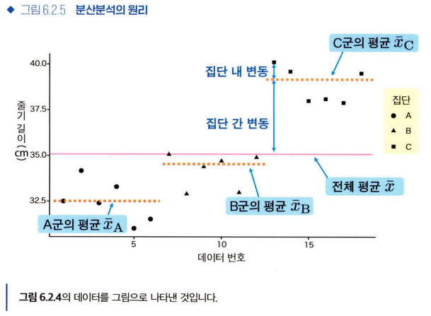